# STAT 6555: Time Series

Dan Park

March 30, 2016

```r
library("astsa")
```

**March 28, 2016**

### Introduction

The analysis of experimental data that have been observed at different points in “time” (usually equally spaced).

- “time” is in quotes because other variables may be used in its place, though time is by far the most common.

The obvious correlation introduced by sampling the adjacent points in time can severly restrict the applicability of conventional statistical methods that assume independent and identically distributed observations.

The first step to analysis is to plot the data as a function of time.

The two statistical methods used to analyze time series data are the

1. time domain approach
2. frequency domain approach

**Methodology**

- first, find a pattern from the data at hand
- then the pattern is extrapolated into the future to prepare a forecast

Assumption? This pattern continues into the future.

**Components**

1. Trend
   - The long-run upward or downward movement of the series.
2. Cycle
   - The upward and downward movement of the series around the trend (think of a wave).
3. Seasonal variations
   - The yearly (weekly, quarterly, …) patterns in the data (think of temperature).
4. Irregular fluctuations
   - The erratic movements in the series that cannot be accounted for by a pattern.

The goal is to only have these irregular fluctuations left after the modleling is done (white noise).

**Example** Johnson & Johnson Quarterly Earnings  
These are quarterly earnings over 84 quarters (21 years) from 1960 to 1980.

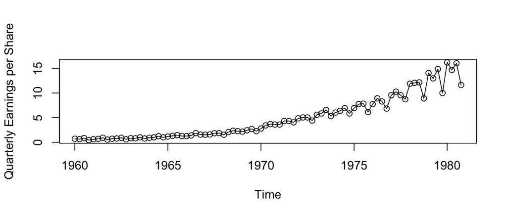

```r
library("astsa")
#Example 1.1: JandJ Quarterly Earnings
plot(jj, type="o", ylab="Quarterly Earnings per Share")
```

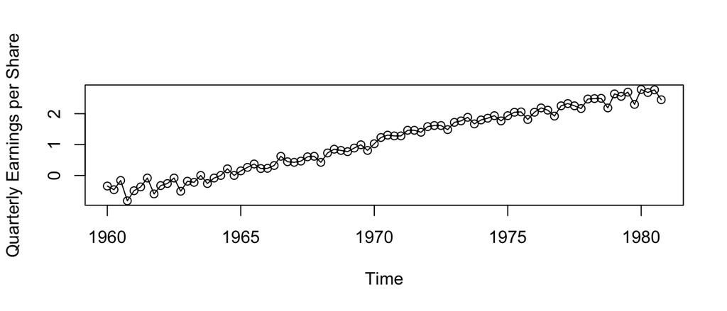

```r
#log transformation:
plot(log(jj), type="o", ylab="Quarterly Earnings per Share")
```

**Example** Global Warming  
The data are global mean land-ocean temperature index from 1880 to 2009, with base period 1951 - 1980. These are deviations, measured in degrees centigrade, from the 1951 - 1980 average.

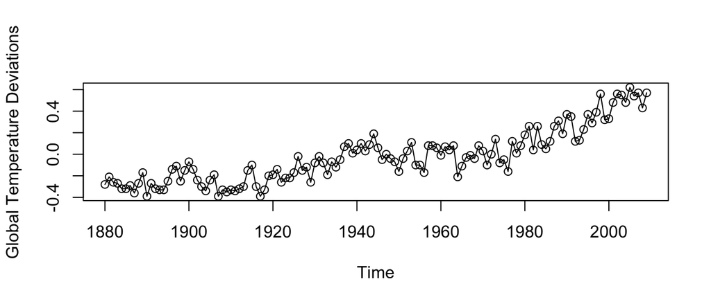

```r
#Example 1.2: Global Warming
plot(gtemp, type="o", ylab="Global Temperature Deviations")
```

**Example** Speech Data  
This is an example to investigate computer recognition of speech. The data shows a 0.1 second sample of recorded speech for the phrase “aaa … hhh,” and note the repetitive nature of the signal and the regular periodicities.

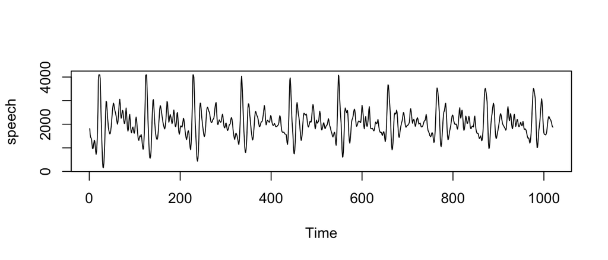

```r
#Example 1.3: Speech Data
plot(speech)
```

**Example** NY Stock Exchange  
Some financial time series the daily returns of the NYSE from February 2, 1984 to December 31, 1991.

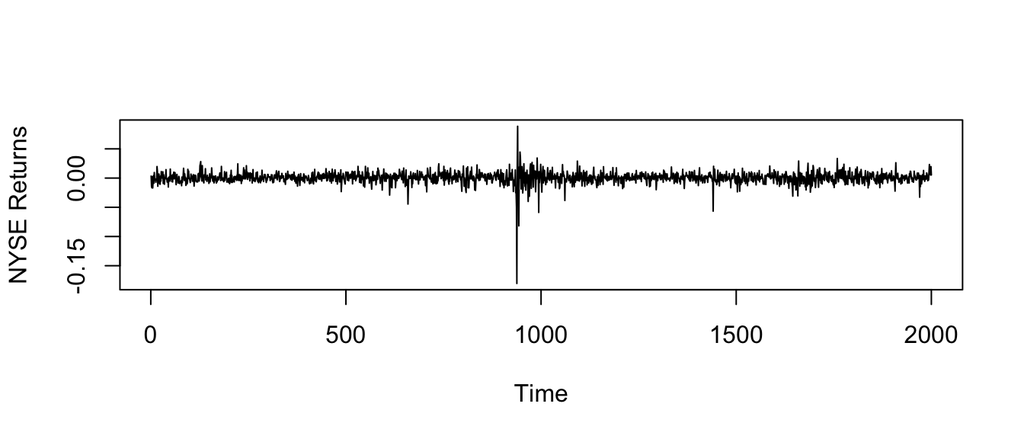

```r
#Example 1.4: NYSE
plot(nyse, ylab="NYSE Returns")
```

**Example** El Nino and Fish Population  
Looking at multiple time series simultaneously. This data represents monthly values of an environmental series called the Southern Oscillation Index (SOI) and associated refruitment (an index of number of new fish). Both series are for a period of 452 months ranging from 1950 to 1987.

SOI measures changes in air pressure related to sea surface temperatures in the Central Pacific Ocean.

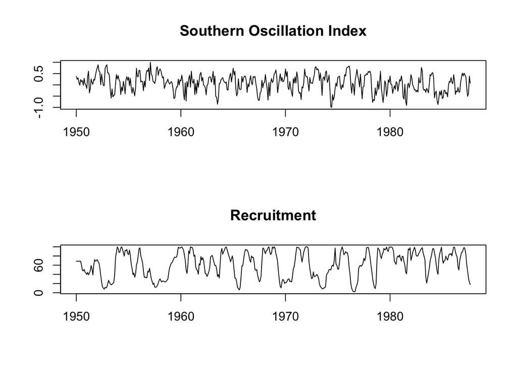

```r
#Example 1.5: El Nino
par(mfrow = c(2,1)) # set up the graphics
plot(soi, ylab="", xlab="", main="Southern Oscillation Index")
plot(rec, ylab="", xlab="", main="Recruitment")
```

**Example** fMRI Imaging  
A collection of independent series or vector of series, generated under varying experimental conditions or treatment configurations we observe data collected from various locations on the brain via functional magnetic resonance imaging (fMRI). Five subjects were given periodic brushes on the hand. The stimulus was applied for 32 seconds and then stopped for 32 seconds. The sample rate was one observation every 2 seconds for 256 seconds ($n=128$). The series are consecutive measures of blood oxygenation-level dependent (BOLD) signal intensity, which measures the activity of the brain.

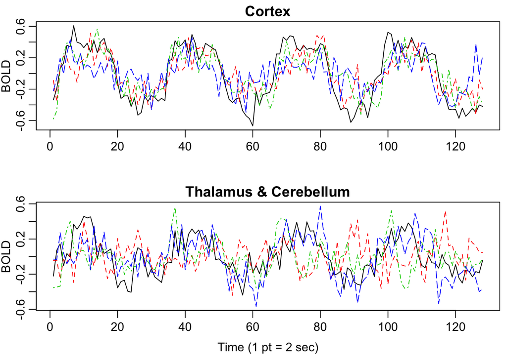

```r
#Example 1.6: fMRI Imaging
par(mfrow=c(2,1), mar=c(3,2,1,0)+.5, mgp=c(1.6,.6,0))
ts.plot(fmri1[,2:5], col=1:4, lty=c(1,2,4,5), ylab="BOLD",
        xlab="", main="Cortex")
ts.plot(fmri1[,6:9], col=1:4, lty=c(1,2,4,5), ylab="BOLD",
        xlab="", main="Thalamus & Cerebellum")
mtext("Time (1 pt = 2 sec)", side=1, line=2)
```

**Wednesday, March 30, 2016**  
**Example** Earthquakes and Explosions  
This represents two phases (or arrivals) along the surface denoted $p(t=1, \dots, 1024)$ and $S(t=1024, \dots 2048)$ at a seismic recording station. The recording instruments in Scandanavia are ovserving earthquake and mining explosions. A general problem of interest is to distinguish or discriminate between waveforms generated by earthquakes and those generated by explosions.

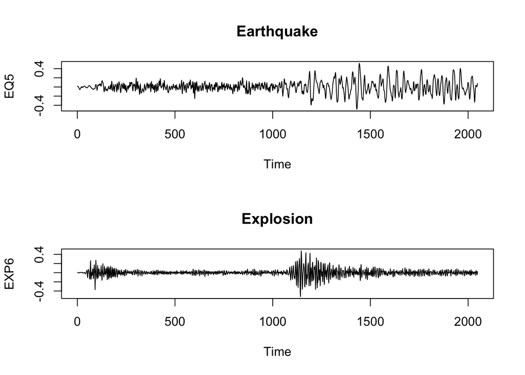

```r
library(astsa)
par(mfrow=c(2, 1))
plot(EQ5, main="Earthquake")
plot(EXP6, main="Explosion")
```

### Models

- **White Noise**: this is a time series generated from uncorrelated variables with mean $0$ and finite variance $\sigma_w^2$, commonly denoted $w_t \sim wn(0, \sigma_w^2)$ ($w$ in time series is typically white noise). We commonly assume that they are independent and identically distributed and we commonly assume that distribution is Gaussian. In which case, we may write $w_t \stackrel{iid}{\sim} N(0, \sigma_w^2)$.

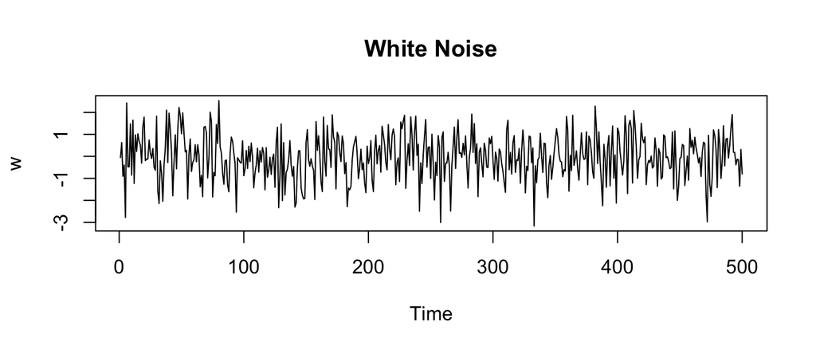

```r
par(mfrow=c(1,1))
w <- rnorm(500)
plot.ts(w, main="White Noise")
```

- **Moving Average and Filtering**: Trying to filter out high frequencies. If we want to smooth the series, we can average the current value with its immediate neighbors, past and future. How many neighbors is something we will discuss later.
  Consider
  $$v_t = \frac{1}{3}(w_{t-1} + t_t + w_{t+1})$$
  reflecting slower oscillations while taking out faster oscillations.

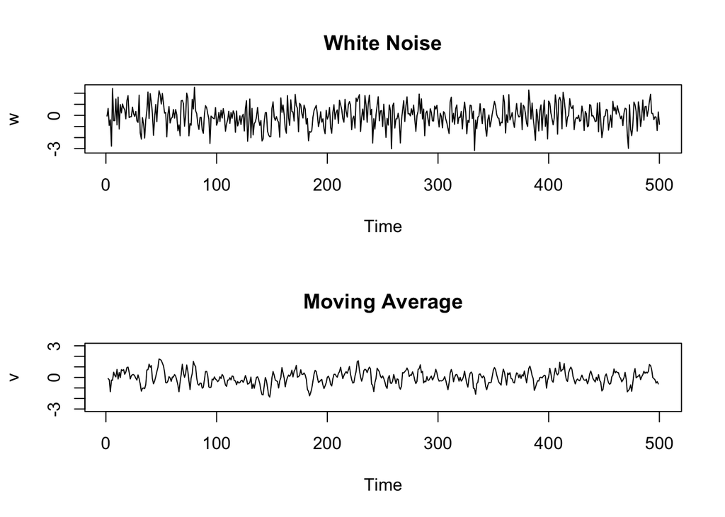

```r
v <- filter(x=w, filter=c(1/3, 1/3, 1/3), sides=2)
par(mfrow=c(2,1))
plot.ts(w, main="White Noise")
plot.ts(v, ylim=c(-3, 3), main="Moving Average")
```

- **Autoregressions**: This is a regression or prediction of the current value, $x_t$, of a time series as a function of past values (how many to be discussed later).  
  This introduces a problem of not having a beginning term since each one is dependent upon two previous terms (i.e. $x_0, x_{-1}, \dots$) (we will tackle this later).
  - **Example** A second-order autoregressive model is
    $$x_t = x_{t-1} - 0.9x_{t-2} + w_t$$
    Once we have the starting values, we just plug into the formula above.

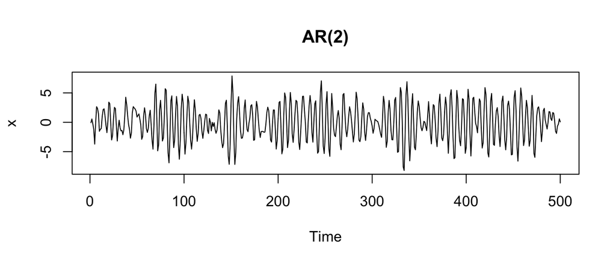

```r
x <- filter(w, filter=c(1, -.9), method='recursive')
plot.ts(x, main='AR(2)')
```

Note that the beginning of the series looks odd. For this reason, we usually introduce a “burn-in” period by adding extra points at the beginning and removing them after the fit.

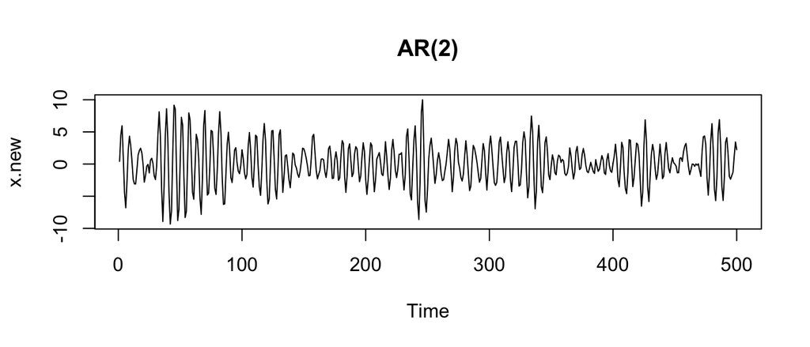

```r
w.new <- rnorm(550) # Add 50 to avoid startup problems
x.new <- filter(w.new, filter=c(1, -.9), method='recursive')[-(1:50)]
plot.ts(x.new, main="AR(2)")
```

- **Random Walk with Drift**: This is a model for analyzing a trend with the initial condition that $x_0 = 0$, given by
  $$x_t = \delta + x_{t-1} + w_t \tag{1}$$
  It’s called a random walk because the value of the time series at time $t$ is the value of the series at time $t-1$ plus a completely random component (movement).
  Using substitution, we can write $(1)$ as
  $$x_t = \delta_t + \sum_{j=1}^t w_j$$
  - **Example** Suppose $\delta = 0$ and $0.3$ and let $\sigma^2 = 1$. Compare the two series.

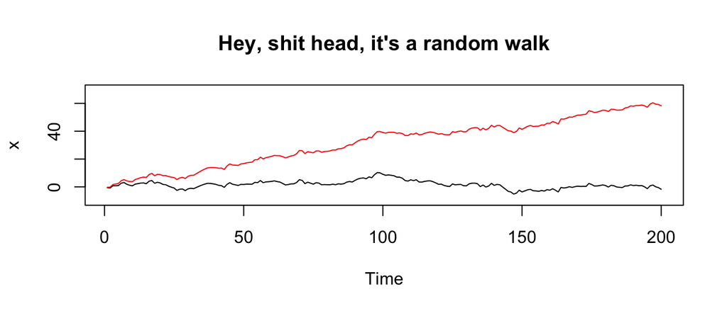

```r
set.seed(123)
w <- rnorm(200)
x <- cumsum(w) # random walk w/o drift
wd <- w + .3
xd <- cumsum(wd) # random walk w/ drift
par(mfrow=c(1,1))
plot.ts(x, ylim=c(-10, 70), main="Hey, shit head, it's a random walk")
lines(xd, col='red') # w/ drift
```

### The Basics

Let the value of the series at some time point $t$ be $x_t$. Then the observed values can be represented as $x_1$, the initial time point, $x_2$, the second time point, and so forth, up until $x_n$, the last ovserved point.

### Measures of Dependence

**Definition** The mean function is defined as
$$\mu_{xt} = E(x_t)$$
provided it exists, where $E$ denotes the usual expectation operator.

The notation specifies which series and at which time we are finding the mean for.

If we only have one series, we would simplify the notation to $\mu_t$

**Example** (Moving Average) Note, the mean of a white noise series is zero at all $t$,
$$\mu_{wt}=E(w_t) = 0 \ \ \ \forall t$$
If we look at the previous moving average example, the mean function is
$$E(v_t) = \frac{1}{3}[E(w_{t-1}) + E(w_t) + E(w_{t+1})] = 0$$
Note, this happens to not be a function of time.

**Problem** (Autoregressive) For the previous autoregressive example ($x_t = x_{t-1} - 0.9x_{t-2} + w_t$), we are assuming the mean is constant, find the mean function.
**Solution** If the mean is constant, then $x_i \ \forall i$ is constant, say, $\mu$
$$\begin{aligned}
E(x_t) &= E[x_{t-1} - 0.9x_{t-2} + w_t] \\
\mu &= E[x_{t-1}] - 0.9E[x_{t-2}] + E[w_t] \\
&= \mu - 0.9\mu + 0 \\
&= 0.1 \mu \\
0.9\mu &= 0 \\
\mu &= 0
\end{aligned}$$

**Example** In the previous problem, consider adding a constant to the model:
$$x_t = c + x_{t-1} - 0.9 x_{t-2} + w_t$$
Then the mean function becomes
$$\begin{aligned}
\mu &= E(x_t) \\
&= E(c + x_{t-1} - 0.9 x_{t-2} + w_t) \\
&= E(c) + E(x_{t-1}) - 0.9 E(x_{t-2}) + E(w_t) \\
&= c + \mu - 0.9 \mu + 0 \\
\mu(1 - 1 + 0.9) &= c \\
\mu &= \frac{c}{0.9}
\end{aligned}$$

**Definition** The autocovariance function is defined as the second moment product
$$\begin{aligned}
\gamma_x (s, t) &= \text{cov}(x_s, x_t) \\
&= E[(x_s - \mu_s)(x_t - \mu_t)]
\end{aligned}$$
for all $s$ and $t$.

The autocovariance measures the linear dependence between two points on the same series, possibly observed at different times.

When $s=t$, we have the variance at time $t$.

$$\gamma(t,t) = E[(x_t - \mu_t)^2] = \text{Var}(x_t)$$

As with most variances, this quantity is usually unknown.

We would have a problem with estimability if we let the variance at time $t$ be different for all $t$ (can’t estimate variance with one observation).

**Monday, April 4, 2016**

**Example** White Noise: For the white noise series $w_t$,
$$\begin{aligned}
\gamma_w(s,t) &= E[(w_s - 0)(w_t - 0)] \\
&= E(w_s w_t) \\
&= \begin{cases}
\begin{array}[lcl] \\
\sigma_w^2, && s=t \\
0, && s \neq t
\end{array}
\end{cases}
\end{aligned}$$

**Example** Moving Average: Find the autocovariance of the moving average series from the previous example
$$v_t = \frac{1}{3}(w_{t-1} + w_t + w_{t+1})$$
$$\begin{aligned}
\gamma_v(s,t) &= E[(v_s - 0)(v_t - 0)] \\
&= E\left[\left(\frac{w_{s-1}}{3} + \frac{w_s}{3} + \frac{w_{s+1}}{3} - 0 \right)\left(\frac{w_{t-1}}{3} + \frac{w_t}{3} + \frac{w_{t+1}}{3} - 0 \right)\right] \\
&= \begin{cases}
\begin{array}[lcl] \\
\frac{3}{9} \sigma^2_w, && s=t \\
\frac{2}{9} \sigma^2_w, && |s-t|=1 \\
\frac{1}{9} \sigma^2_w, && |s-t|=2 \\
0, && |s-t| \geq 3
\end{array}
\end{cases}
\end{aligned}$$
This is interesting because it doesn’t matter where in the series you are, only the distance between the points matters.

**Problem** Random Walk: Find the autocovariance of the random walk with drift. Use $x_t = \delta_t + \sum_{j=1}^t w_j$.
**Solution** Recall the mean function: $\mu_t = \delta_t$
$$\begin{aligned}
\delta_x(s,t) &= E[(x_s - \delta_s)(x_t - \delta_t)] \\
&= E[(x_s - \mu_s)(x_t - \mu_t)] \\
&= E[(\delta_s + \sum_{j=1}^s w_j - \delta_s)(\delta_t + \sum_{i=1}^t w_i - \delta_t)] \\
&= E \left[\sum_{j=1}^s w_j \sum_{i=1}^t w_i \right] \\
&= E(w_1 w_1 + w_1w_2 + \cdots + w_sw_t) \\
&= min(s,t)\sigma^2_w
\end{aligned}$$
So does drift matter? Answer: No. Autocovariance function is the same without the drift.

**Definition** The autocorrelation function (ACF) is defined as
$$\rho (s,t) = \frac{\gamma(s,t)}{\sqrt{\gamma(s,s) \gamma(t,t)}}$$
As before, this is a measure of linear dependence and can be viewed as a masure of linear predictability of the series at time $t, x_t$, using only $x$ values.

**Example** Moving Average: Find the ACF
$$\rho(s,t) =
\begin{array}[lcl] \\
\begin{cases}
1, && |s-t| = 0 \\
\frac{2}{3}, && |s-t| = 1 \\
\frac{1}{3}, && |s-t| = 2 \\
0, && |s-t| \geq 3
\end{cases}
\end{array}$$
The derivations come from our derived values for the moving averages example for autocovariance. For example, for $|s-t|=1$,
$$\begin{aligned}
\rho (s,t) &= \frac{\gamma(s,t)}{\sqrt{\gamma(s,s) \gamma(t,t)}} \\
&= \frac{\frac{2}{9} \sigma_w^2}{\sqrt{\frac{1}{3} \sigma_w^2 \frac{1}{3} \sigma_w^2}} \\
&= \frac{\frac{2}{9} \sigma_w^2}{\frac{1}{3} \sigma_w^2} \\
&= \frac{2}{3}
\end{aligned}$$
The ability to make predictions between time points depends on the distance. Further distances away make the predictability more difficult. After 3 or more in distance, we have no information to make a prediction.

**Definition** The cross-covariance function between two series $x_t$ and $y_t$, is
$$\begin{aligned}
\gamma_{xy}(s,t) &= \text{Cov}(x_s, y_t) \\
&= E[(x_s - \mu_{xs})(y_t - \mu_{yt})] \\
\end{aligned}$$
Scaling to the interval $[-1,1]$, we have

**Definition** The cross-correlation function (CCF) is defined as
$$\rho_{xy}(s,t) = \frac{\gamma_{xy}(s,t)}{\sqrt{\gamma_x(s,s) \gamma_y(t,t)}}$$

### Stationary Time Series

**Strict stationarity**: A stationary time series is one which the statistical behavior of $x_{t_1}, x_{t_2}, \dots, x_{t_k}$ is identical to that of the shifted set $x_{t_1 + h}, x_{t_2 + h}, \dots, x_{t_k + h}$ for any collection of time points $t_1, t_2, \dots, t_k$ and for any shift (lag) $h$. Unfortunately, this definition is too strong for most applications.

There exists a weaker version that only puts constraints on the first two moments.

**Definition** A weakly stationary time series is a finite variance process where the following two conditions must be met

1. the mean value function, $\mu_t$, is a constant and does not depend on time $t$.
2. the autocovariance function $\gamma(s,t)$ depends on $s$ and $t$ only through their difference $|s-t|=h$.

So $E(x_t) = \mu$ for all $t$ and
$$\gamma_x(h) = E[(x_{t+h} - \mu)(x_t - \mu)]$$
Note that $\gamma(h)=\gamma(-h)$ since
$$\begin{aligned}
\gamma(h) &= \gamma(t+h-t) \\
&= E[(x_{t+h} - \mu)(x_t - \mu)] \\
&= E[(x_t - \mu)(x_{t+h} - \mu)] \\
&= \gamma(-h)
\end{aligned}$$
Because of this property, plotting the ACF and ACovF wrt to $h$ does not require including the negative lag. The function is symmetric about $h=0$.

The autocorrelation function becomes
$$\rho_x(h) = \frac{\gamma_x(h)}{\gamma_x(0)}$$
$\rho_x(h)$ still remains between $-1$ and $1$.

**Example** Let $w_t$ be white noise, that is $w_t \stackrel{iid}{\sim} (0, \sigma^2_w = 1)$ and $x_t = w_t - 0.9w_{t-1}$. This is called a first-order moving average series.  
Here, $E(x_t)=0 - 0.9 \cdot 0 =0$ and $(w^2_t)=1$.

How to simulate a series

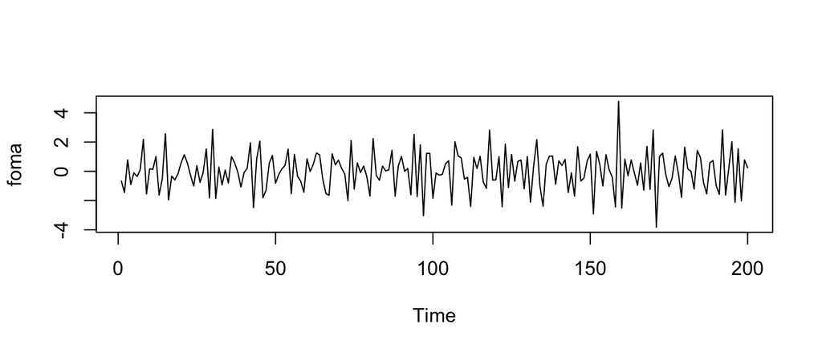

```r
# what this all means will be explained in a future lecture
# first order moving avg
foma <- arima.sim(model=list(order=c(0,0,1), ma=-0.9), n=200) # 200 obs
plot.ts(foma)
```

**Problem** Is a random walk weakly stationary?  
**Solution** With drift, clearly the mean function depends on $t$. So it is not stationary.  
Without drift, $\gamma_x(h)=min(t+h,t)\sigma_w^2$, which clearly depends on $t$. So this is also not stationary.

**Example** Is $x_t=\beta_0 + \beta_1 t + w_t$ weakly stationary?  
**Solution** No, since $E(x_t) = \beta_0 + \beta_1t$ which depends on $t$.  
Ignore the mean function and consider the second criteria for a weakly stationary time series. Is the autocovariance function dependent on $|s-t|=h$? It is not a function of $t$. We may consider the series as having stationary behavior around a linear trend, called **trend stationarity**.